# Biodiversity in Vancouver Parks

Lesley Miller

07/06/2020

## Introduction

The primary interest of this project was to explore the intersection between Vancouver, BC parks and geotagged species occurrence data obtained from the [Global Biodiversity Information Facility](https://www.gbif.org/), known from here on as GBIF. Any Vancouverite would be proud of our city parks and greenspaces as they serve as immense community resources with multifunctional benefits. Given that urban parks may be the primary interface with nature and wildlife for a great number of residents, this project attempted to answer how much species occurrence data has been collected in Vancouver parks over the last 11 years. The analysis answers 3 main questions:

1. What proportion of Vancouver’s biodiversity data is recorded in an urban park?
2. Which parks contain the most observations?
3. Which parks contain the largest number of different species?

To answer these questions, the analysis makes use of two main data sources: Species occurrence data from [GBIF](https://www.gbif.org/) and spatial parks data from the [BC Data Catalogue](https://catalogue.data.gov.bc.ca/dataset/local-and-regional-greenspaces). The tables below allows a peak at the data underlying the analysis. Only the first few rows of each dataset are shown. Click on the dataset name under **Data Sources** section to reveal the datasets.

The GBIF contained 5,110 different observations and 882 unique species spanning 11 years from 2009 to 2019. All records are from human observation. As can be seen in the **GBIF Data**, each record contains the full taxonomy, geolocation, as well as the date and time an observation was recorded.

The parks data contains information for 234 parks having a range of primary park uses; the main use is just **Park** but the dataset also contains other types of greenspaces like athletic parks, golf courses and playgrounds. Though **Pacific Spirit Park** is a regional park and not technically park of City of Vancouver parks, this gem of an urban forest adjacent to the City of Vancouver was still included in this analysis.

Primary Uses of Vancouver Parks

| Park Type | Frequency |
| --- | --- |
| Athletic | 5 |
| Golf Course | 6 |
| Green Space | 3 |
| Park | 211 |
| Playground | 2 |
| Plaza | 1 |
| School Park | 1 |
| Trail | 4 |
| Water Access | 1 |

## Data Sources

### GBIF Data

| kingdom | phylum | class | order | family | genus | species | latitude | longitude | timestamp | day | month | year | basis_of_record | geometry |
| --- | --- | --- | --- | --- | --- | --- | --- | --- | --- | --- | --- | --- | --- | --- |
| Fungi | Basidiomycota | Dacrymycetes | Dacrymycetales | Dacrymycetaceae | Dacrymyces | Dacrymyces chrysospermus | 49.30549 | -123.1385 | 2015-02-08T13:15:50Z | 8 | 2 | 2015 | HUMAN_OBSERVATION | POINT (-123.1385 49.30549) |
| Animalia | Chordata | Aves | Anseriformes | Anatidae | Branta | Branta canadensis | 49.27978 | -123.1390 | 2015-02-08T16:28:30Z | 8 | 2 | 2015 | HUMAN_OBSERVATION | POINT (-123.139 49.27978) |
| Animalia | Chordata | Aves | Anseriformes | Anatidae | Anas | Anas platyrhynchos | 49.27640 | -123.1455 | 2015-02-09T08:50:46Z | 9 | 2 | 2015 | HUMAN_OBSERVATION | POINT (-123.1455 49.2764) |
| Animalia | Chordata | Aves | Anseriformes | Anatidae | Lophodytes | Lophodytes cucullatus | 49.27964 | -123.1393 | 2015-02-09T08:42:00Z | 9 | 2 | 2015 | HUMAN_OBSERVATION | POINT (-123.1393 49.27964) |
| Animalia | Chordata | Aves | Passeriformes | Emberizidae | Melospiza | Melospiza melodia | 49.28541 | -123.1433 | 2015-02-09T09:51:57Z | 9 | 2 | 2015 | HUMAN_OBSERVATION | POINT (-123.1433 49.28541) |
| Animalia | Chordata | Aves | Charadriiformes | Laridae | Larus | Larus canus | 49.28363 | -123.1428 | 2015-02-09T10:01:37Z | 9 | 2 | 2015 | HUMAN_OBSERVATION | POINT (-123.1428 49.28363) |
| Plantae | Tracheophyta | Magnoliopsida | Sapindales | Sapindaceae | Acer | Acer circinatum | 49.25005 | -123.2265 | 2018-04-29T14:40:11Z | 29 | 4 | 2018 | HUMAN_OBSERVATION | POINT (-123.2265 49.25005) |
| Animalia | Chordata | Reptilia | Testudines | Emydidae | Chrysemys | Chrysemys picta | 49.30068 | -123.1379 | 2018-06-14T15:27:00Z | 14 | 6 | 2018 | HUMAN_OBSERVATION | POINT (-123.1379 49.30068) |

### Parks Data

| park_name | park_type | park_prima | species_count | species_richness |
| --- | --- | --- | --- | --- |
| Kensington Park | Local | Park | 0 | 0 |
| Kerrisdale Centennial Park | Local | Park | 0 | 0 |
| Kerrisdale Park | Local | Park | 0 | 0 |
| Killarney Park | Local | Park | 0 | 0 |
| Kingcrest Park | Local | Park | 0 | 0 |
| Kinross Ravine Park | Local | Park | 0 | 0 |
| Kitsilano Beach Park | Local | Park | 5 | 4 |
| Langara Golf Course | Local | Golf Course | 1 | 1 |

# Data Processing Pipeline

## Data Cleaning

The raw GBIF data was first obtained through their API and then clipped to a gridded boundary obtained from the City of Vancouver Open Data Portal. The data was then cleaned by removal of unnecessary columns. The parks dataset underwent only minimal processing to retain only necessary columns for downstream analysis.

## Data Preparation

Since the analysis is visual, the data was then processed to produce new data that could be fed into a multi-layer map. The GBIF data points were clipped to within the park boundaries so that total observation counts as well as the count of unique species per park could be calculated. The clipped GBIF data and the parks along with its species metrics then became data layers in a **keplergl** map available [here for exploration](https://aromatic-toast.github.io/vancouver_park_biodiversity/results/final_report_map.html).

This analysis was carried out with the amazing help from the following open source **R** packages: **R** (R Core Team 2019), **tidyverse** (Wickham 2017), **here** (Müller 2017), **gridExtra** (Auguie 2017) and **sf** (Pebesma 2018).

And the following **Python** packages: **Python** (Van Rossum and Drake 2009), **GeoPandas** (“GeoPandas 0.7.0¶,” n.d.), **Pandas** (“Pandas,” n.d.) and **keplergl** (“Large-Scale Webgl-Powered Geospatial Data Visualization Tool,” n.d.).

# Results

## Observation Hotspots

*What proportion of Vancouver’s biodiversity data is recorded in an urban park?*

The pie chart in **Proportion in Parks** indicates that about half of the GBIF data for Vancouver was observed in a park with the true percentage about 51%.

*Which parks contain the most observations?*

### Proportion In Parks

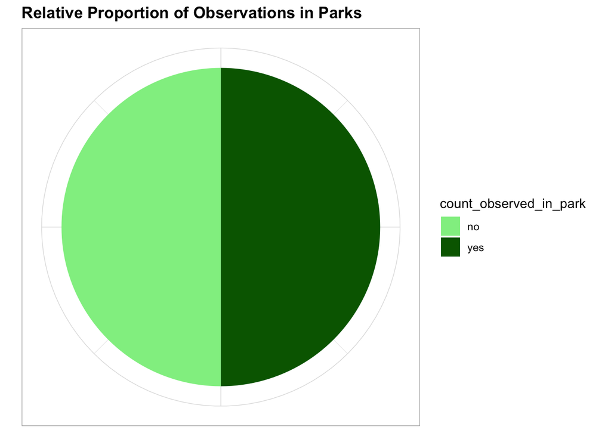

### Outliers

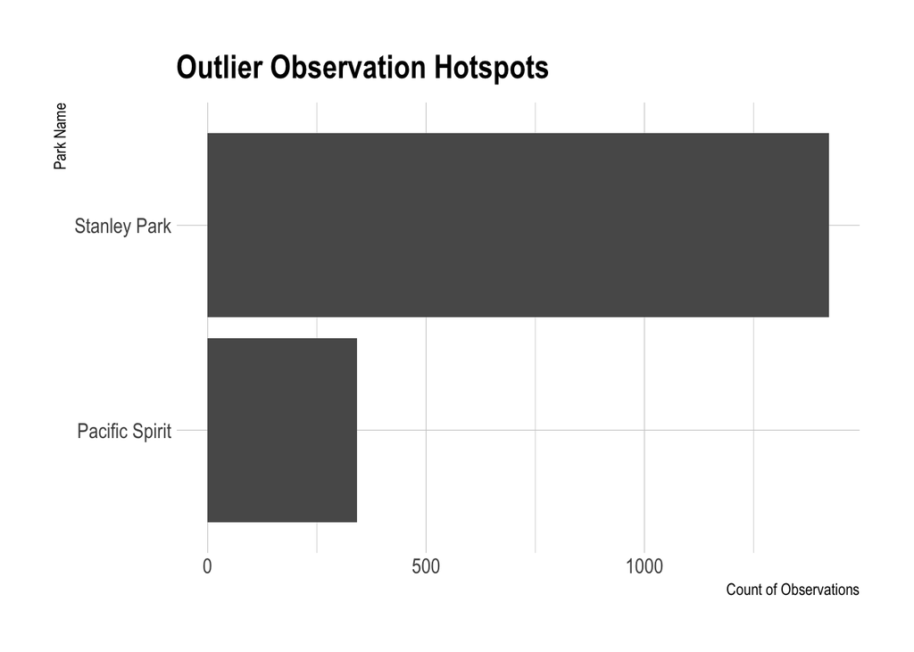

### No Outliers

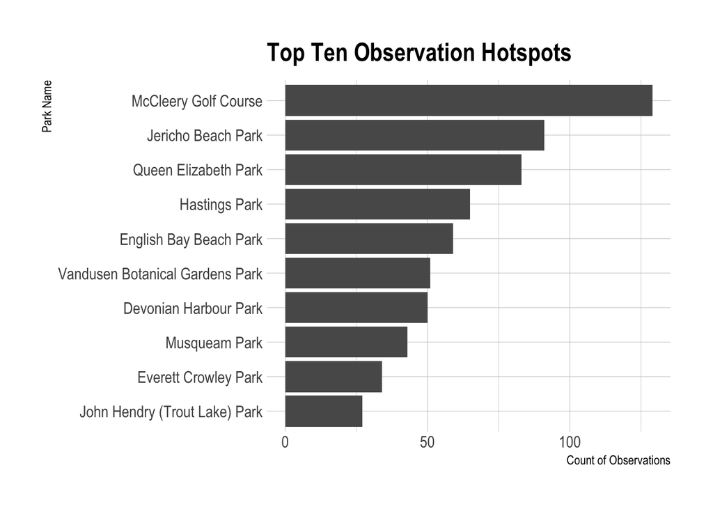

## Highest Unique Species

*Which parks contain the largest number of different species?*

The distribution of unique species is very similar to the top ten observation counts. The two winning outliers are again **Stanley Park** and **Pacific Spirit**. For the top ten excluding outliers, **McCleery Golf Course** wins again with the highest number of different species observed. After the winner, the rankings shift a bit compared to the observation counts with nine parks being in the the top ten for both metrics. However, for **Point Grey Golf and Country Club**, it makes the top ten for higher count of unique species but does not appear in the top ten for total observations.

### Outliers

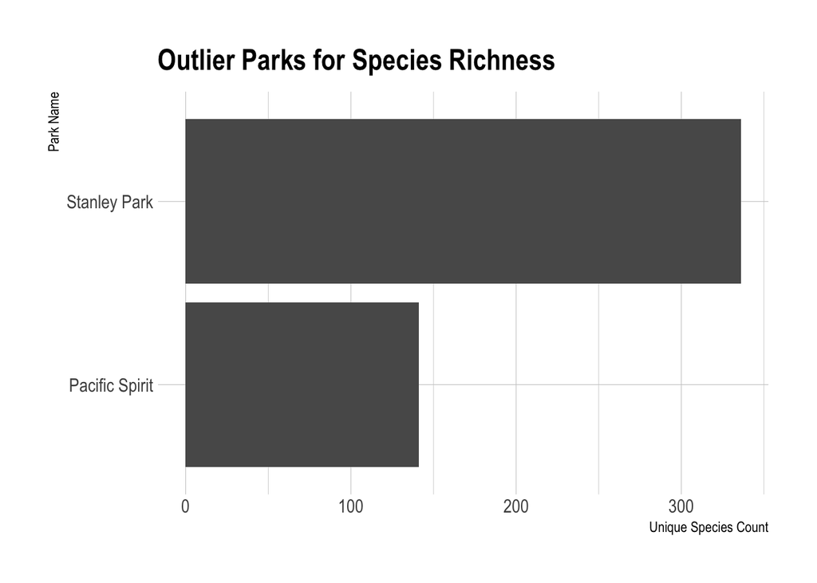

### No Outliers

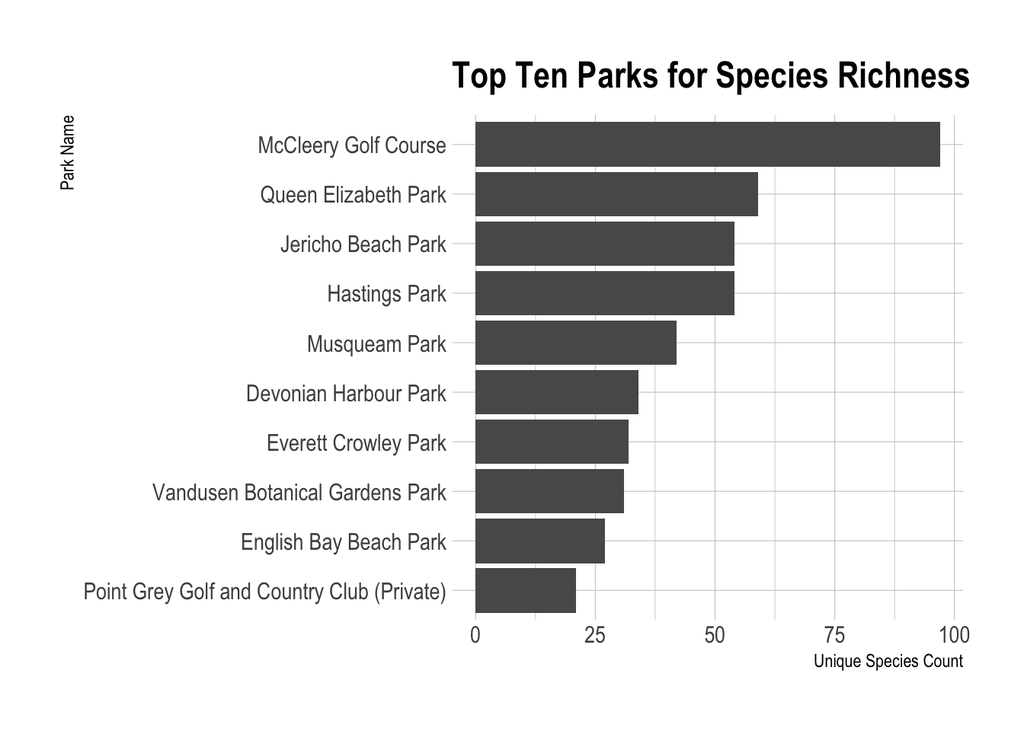

## Mapping Park Observation Hotspots

The primary visualization product is a spatial map of Vancouver that includes park polygons and species observation data that was processed by the data pipeline. The map was produced using **keplergl** (“Large-Scale Webgl-Powered Geospatial Data Visualization Tool,” n.d.) and can be explored interactively.

### Interactive Map Instructions

1. Click on the *greather than* symbol in the top left corner to reveal the hidden control panel. This panel allows the user to view the data layers of the map. The map consists of 3 data layers; **species observations (points)**, **park outliers (polygons)** and the **non-outlier parks (polygons).** All layers are turned on by default but can be toggled on and off by clicking on the **eye icon** on the layer. Thus a user can view the outlier parks and non-outliers together or separately by adjusting which layers are visible. Click on the **icon 3rd from the top right corner** to reveal the map legend.
2. Zoom in on points and polygons to examine regions of interest.
3. Mouse over spatial features, either points or polygons to reveal a tooltip that displays information about that observation. The tooltip for the polygons displays the count metrics for parks (e.g observation count and unique species count) while the tool tip for a species observation includes the full taxonomy information as well as the type of record that was recorded. Zoom in closely on points to view the tooltip.
4. By default, the map colours each park by **unique_species_count**. A user may change this by pressing the downward pointing arrow to expand the **parks**/**park_outliers** layers. By selecting **Fill Color**, a user can change the **Color Based On** option to color the parks based on the **obsevation_count**.

[interactive chart not shown]

# Conclusion

This project explored the urban parks and species observations of Vancouver, BC. A key curiosity at the start of this project was how much citizen science data is recorded in Vancouver parks. Given how sparse the GBIF data is for Vancouver, there is only ~5,000 observations over an 11 year period, it was thought at the beginning that perhaps not many observations would be found in these places or perhaps they would be extremely clustered in only a few parks. It turns out that just over half of the data collected was found within parks, an unexpected result. This reinforces the presumption at the start of this project that urban parks serve as a gateway for residents to observe and interact with their natural environment. Though half the observations are found in only two parks, there are a number of other parks scattered across the landscape that serve as observation hotspots.

A future analysis would look at not only raw observation counts per park but also incorporate park size as most of the large parks also tend ot have large numbers of observations. An additional metric might compare parks based on their observations per unit area.

This brief dive into Vancouver parks underscores the incredible asset of **Stanley Park** to our urban landscape and provides support for the continued stewardship of these most precious resources.

# References

Auguie, Baptiste. 2017. *GridExtra: Miscellaneous Functions for "Grid" Graphics*. https://CRAN.R-project.org/package=gridExtra.

“GeoPandas 0.7.0¶.” n.d. *GeoPandas 0.7.0 - GeoPandas 0.7.0 Documentation*. https://geopandas.org/.

“Large-Scale Webgl-Powered Geospatial Data Visualization Tool.” n.d. *Kepler.gl*. https://kepler.gl/.

Müller, Kirill. 2017. *Here: A Simpler Way to Find Your Files*. https://CRAN.R-project.org/package=here.

“Pandas.” n.d. *Pandas*. https://pandas.pydata.org/.

Pebesma, Edzer. 2018. “Simple Features for R: Standardized Support for Spatial Vector Data.” *The R Journal* 10 (1): 439–46. https://doi.org/10.32614/RJ-2018-009.

R Core Team. 2019. *R: A Language and Environment for Statistical Computing*. Vienna, Austria: R Foundation for Statistical Computing. https://www.R-project.org.

Van Rossum, Guido, and Fred L. Drake. 2009. *Python 3 Reference Manual*. Scotts Valley, CA: CreateSpace.

Wickham, Hadley. 2017. *Tidyverse: Easily Install and Load the ’Tidyverse’*. https://CRAN.R-project.org/package=tidyverse.